# Project 5: Communicate data findings - Flights Dataset

## by: Amnah Aldayri

## Investigation Overview

> This project aim to Investe the interactions of the flight features and understand the correlations between them.

## Dataset Overview

> Flights Dataset consists of flight arrival and departure details for all commercial flights within the USA, from October 1987 to April 2008. This is a large dataset: there are nearly 120 million records in total, and takes up 1.6 gigabytes of space compressed and 12 gigabytes when uncompressed.

## Univariate Exploration

> What is the most commonly used Carrier Company?

> From the diagram above, we can observe that WN is the most commonly used Carrier Company in 2007 and 2008.

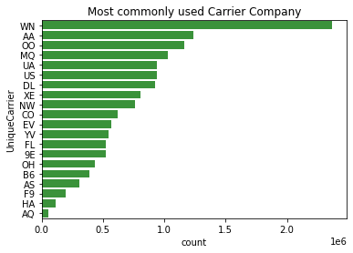

## Bivariate Exploration

> What is the correlation between Month and weather Delay?

> From the diagram above, we can observe that December (12) is the most month has weather Delay.

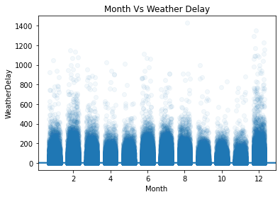

## Multivariate Exploration

> Correlation between Time (Year , Month) and Delay type (CarrierDelay , WeatherDelay ,NASDelay , SecurityDelay , LateAircraftDelay)

> From the diagram, we can observe many types of delays, LateAircraftDelay is the highest one, While the SecurityDelay is the lowest one.

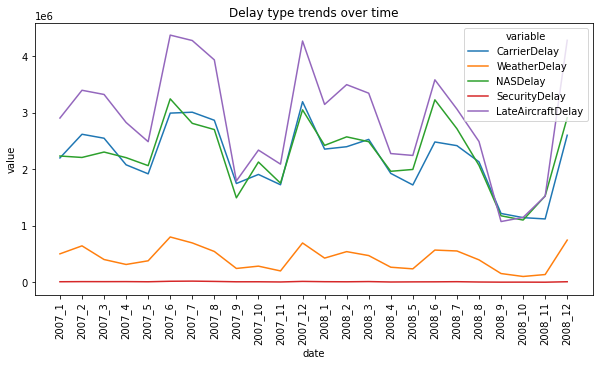